# CMP330 Data Analytics - Assessment 2 (Pre-Assignment)

MD Ali Hasan Jidan (B01011849)

# Introduction

This notebook contains my solution to the CMP330 Assessment 2 pre-assignment. The goal is to classify cars according to their **acceptability** (`unacc`, `acc`, `good`, `vgood`) based on six categorical features (`buying`, `maint`, `doors`, `persons`, `lug_boot`, `safety`) using several machine learning algorithms.

# Part 1: Exploratory Data Analysis and Data Preparation

## 1.1 Loading the data

The dataset is read in and every column is converted to a factor, since all variables (including the target) are categorical rather than numeric.

```r
car_data <- read.csv("car.csv")
car_data <- data.frame(lapply(car_data, factor))

head(car_data)
```

|  | buying | maint | doors | persons | lug_boot | safety | acceptability |
| --- | --- | --- | --- | --- | --- | --- | --- |
| 1 | vhigh | low | 5more | 4 | small | low | unacc |
| 2 | high | vhigh | 3 | 2 | med | low | unacc |
| 3 | vhigh | high | 4 | 4 | big | med | unacc |
| 4 | high | vhigh | 5more | 4 | med | low | unacc |
| 5 | vhigh | high | 5more | 2 | med | high | unacc |
| 6 | med | vhigh | 4 | more | small | med | unacc |

```r
str(car_data)
```

```
'data.frame':   1000 obs. of  7 variables:
 $ buying       : Factor w/ 4 levels "high","low","med",..: 4 1 4 1 4 3 3 2 3 3 ...
 $ maint        : Factor w/ 4 levels "high","low","med",..: 2 4 1 4 1 4 3 4 2 2 ...
 $ doors        : Factor w/ 4 levels "2","3","4","5more": 4 2 3 4 4 3 3 1 3 3 ...
 $ persons      : Factor w/ 3 levels "2","4","more": 2 1 2 2 1 3 1 3 2 3 ...
 $ lug_boot     : Factor w/ 3 levels "big","med","small": 3 2 1 2 2 3 1 1 3 1 ...
 $ safety       : Factor w/ 3 levels "high","low","med": 2 2 3 2 1 3 3 1 3 3 ...
 $ acceptability: Factor w/ 4 levels "acc","good","unacc",..: 3 3 3 3 3 3 3 1 1 2 ...
```

## 1.2 Basic frequency counts

Before modelling, it’s useful to see how the classes are distributed and how individual features relate to the target label.

```r
# How many cars fall into each acceptability class?
table(car_data$acceptability)
```

```
  acc  good unacc vgood
  231    41   693    35
```

```r
# Cross-tabulation: buying price vs acceptability
table(car_data$buying, car_data$acceptability)
```

```
        acc good unacc vgood
  high   72    0   198     0
  low    51   27   138    22
  med    68   14   162    13
  vhigh  40    0   195     0
```

```r
# Cross-tabulation: safety vs acceptability (an extra one I added, since
# safety is intuitively a strong predictor of acceptability)
table(car_data$safety, car_data$acceptability)
```

```
       acc good unacc vgood
  high 131   19   145    35
  low    0    0   337     0
  med  100   22   211     0
```

```r
summary(car_data)
```

```
   buying      maint       doors     persons     lug_boot    safety    acceptability
 high :270   high :242   2    :243   2   :321   big  :341   high:330   acc  :231
 low  :238   low  :248   3    :246   4   :343   med  :324   low :337   good : 41
 med  :257   med  :259   4    :259   more:336   small:335   med :333   unacc:693
 vhigh:235   vhigh:251   5more:252                                     vgood: 35
```

## 1.3 Visualising the distributions

I used `ggplot2` to visualise the target distribution on its own, and then broken down by other features to get a first impression of which variables might be useful predictors.

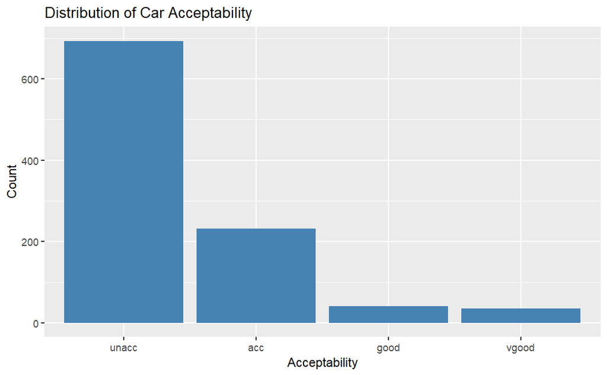

```r
library(ggplot2)

# Fix the ordering of the acceptability levels so charts read logically
car_data$acceptability <- factor(car_data$acceptability,
                                  levels = c("unacc", "acc", "good", "vgood"))

# Overall distribution of the target class
ggplot(car_data, aes(x = acceptability)) +
  geom_bar(fill = "steelblue") +
  labs(title = "Distribution of Car Acceptability",
       x = "Acceptability", y = "Count")
```

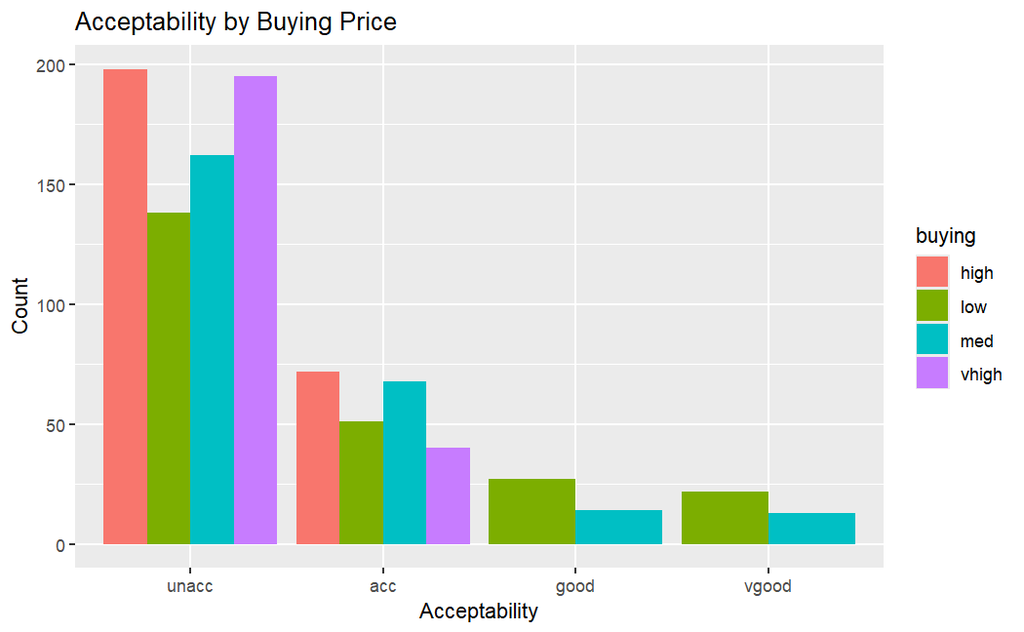

```r
# Acceptability broken down by buying price
ggplot(car_data, aes(x = acceptability, fill = buying)) +
  geom_bar(position = "dodge") +
  labs(title = "Acceptability by Buying Price",
       x = "Acceptability", y = "Count")
```

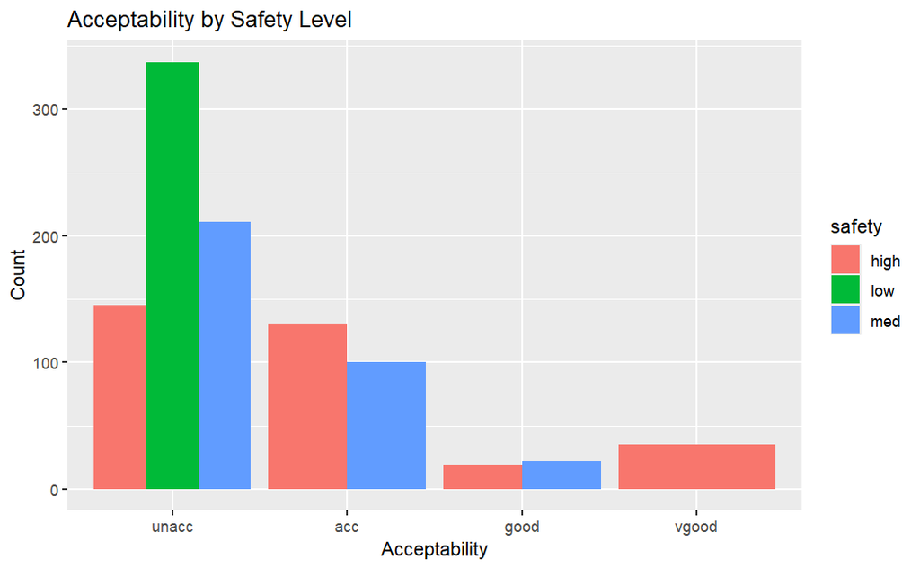

```r
# Extra plot: acceptability broken down by safety level
ggplot(car_data, aes(x = acceptability, fill = safety)) +
  geom_bar(position = "dodge") +
  labs(title = "Acceptability by Safety Level",
       x = "Acceptability", y = "Count")
```

## 1.4 Mutual information between variables

Since none of the variables are numeric, Pearson correlation isn’t appropriate. Instead, I used **mutual information** from the `infotheo` package, which measures how much knowing one categorical variable reduces uncertainty about another.

```r
# install.packages("infotheo")
library(infotheo)

mi_matrix <- mutinformation(car_data)
mi_matrix
```

```
                   buying       maint        doors     persons     lug_boot
buying        1.384665780 0.002630072 0.0026151109 0.001730250 0.0012781665
maint         0.002630072 1.385994865 0.0024207885 0.001993803 0.0006089410
doors         0.002615111 0.002420789 1.3859951924 0.001125010 0.0015724629
persons       0.001730250 0.001993803 0.0011250103 1.098231785 0.0014514422
lug_boot      0.001278166 0.000608941 0.0015724629 0.001451442 1.0983887270
safety        0.001601456 0.001308771 0.0003522822 0.001774065 0.0001767061
acceptability 0.067509707 0.059097457 0.0039909755 0.149276771 0.0173662202
                    safety acceptability
buying        0.0016014559   0.067509707
maint         0.0013087713   0.059097457
doors         0.0003522822   0.003990976
persons       0.0017740655   0.149276771
lug_boot      0.0001767061   0.017366220
safety        1.0985753063   0.191538120
acceptability 0.1915381199   0.840929362
```

```r
# Mutual information of every feature with the target (acceptability is
# column 7)
mi_matrix[-7, 7]
```

```
     buying       maint       doors     persons    lug_boot      safety
0.067509707 0.059097457 0.003990976 0.149276771 0.017366220 0.191538120
```

I also visualised this as a simple heatmap so the strongest relationships are easier to spot at a glance:

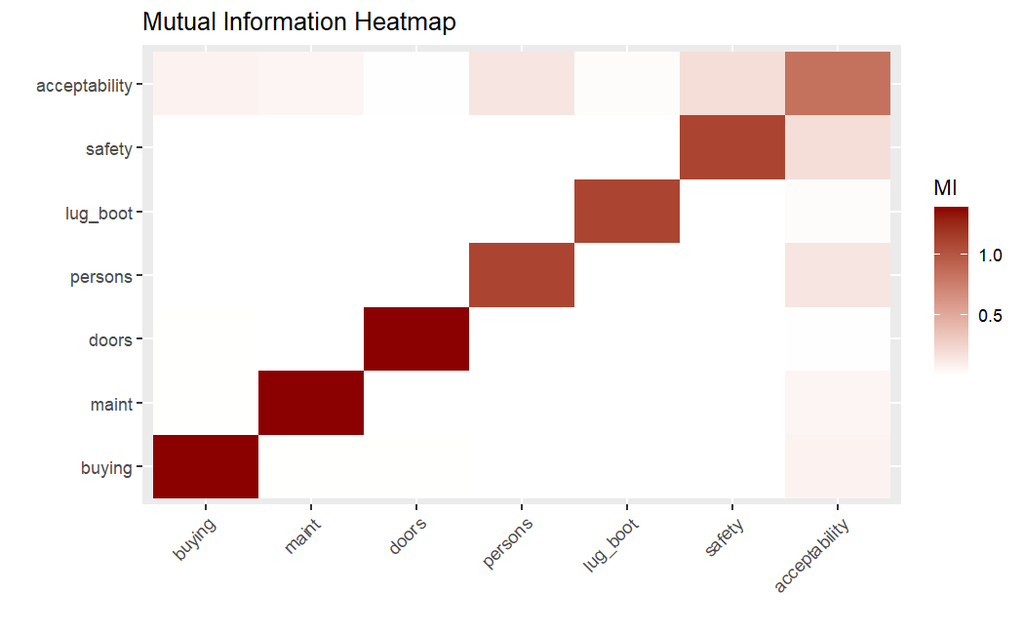

```r
library(reshape2)

mi_melted <- melt(mi_matrix)
ggplot(mi_melted, aes(x = Var1, y = Var2, fill = value)) +
  geom_tile() +
  scale_fill_gradient(low = "white", high = "darkred") +
  labs(title = "Mutual Information Heatmap", x = "", y = "", fill = "MI") +
  theme(axis.text.x = element_text(angle = 45, hjust = 1))
```

## 1.5 Chi-squared tests of independence

A chi-squared test checks whether two categorical variables are statistically independent.

```r
chisq.test(car_data$buying, car_data$acceptability)
```

```
    Pearson's Chi-squared test

data:  car_data$buying and car_data$acceptability
X-squared = 113.82, df = 9, p-value < 2.2e-16
```

```r
chisq.test(car_data$buying, car_data$maint)
```

```
    Pearson's Chi-squared test

data:  car_data$buying and car_data$maint
X-squared = 5.3384, df = 9, p-value = 0.8039
```

```r
# Extra test: is safety independent of acceptability?
chisq.test(car_data$safety, car_data$acceptability)
```

```
    Pearson's Chi-squared test

data:  car_data$safety and car_data$acceptability
X-squared = 294.47, df = 6, p-value < 2.2e-16
```

## 1.6 Train/test split

As specified in the assignment brief, the data is split 80/20 using a fixed seed so that results are reproducible and comparable across students. **This exact code must be used as given.**

```r
library(caTools)
set.seed(123)
split <- sample.split(car_data$acceptability, SplitRatio = 0.8)
car_train <- subset(car_data, split == TRUE)
car_test  <- subset(car_data, split == FALSE)

summary(car_train$acceptability)
```

```
unacc   acc  good vgood
  554   185    33    28
```

```r
summary(car_test$acceptability)
```

```
unacc   acc  good vgood
  139    46     8     7
```

```r
prop.table(table(car_train$acceptability))
```

```
  unacc     acc    good   vgood
0.69250 0.23125 0.04125 0.03500
```

```r
prop.table(table(car_test$acceptability))
```

```
unacc   acc  good vgood
0.695 0.230 0.040 0.035
```

# Part 2a: Application of Machine Learning Algorithms

Each of the five required algorithms is trained on `car_train` and evaluated on `car_test` using a confusion matrix (accuracy, kappa, per-class sensitivity/specificity, etc.).

### Decision Tree (C5.0)

```r
library(caret)
library(C50)

tree_model <- C5.0(car_train[-7], car_train$acceptability)
tree_pred  <- predict(tree_model, car_test)
confusionMatrix(tree_pred, car_test$acceptability)
```

```
Confusion Matrix and Statistics

          Reference
Prediction unacc acc good vgood
     unacc   136   1    0     0
     acc       3  43    1     0
     good      0   2    7     0
     vgood     0   0    0     7

Overall Statistics

               Accuracy : 0.965
                 95% CI : (0.9292, 0.9858)
    No Information Rate : 0.695
    P-Value [Acc > NIR] : < 2.2e-16

                  Kappa : 0.925

 Mcnemar's Test P-Value : NA

Statistics by Class:

                     Class: unacc Class: acc Class: good Class: vgood
Sensitivity                0.9784     0.9348      0.8750        1.000
Specificity                0.9836     0.9740      0.9896        1.000
Pos Pred Value             0.9927     0.9149      0.7778        1.000
Neg Pred Value             0.9524     0.9804      0.9948        1.000
Prevalence                 0.6950     0.2300      0.0400        0.035
Detection Rate             0.6800     0.2150      0.0350        0.035
Detection Prevalence       0.6850     0.2350      0.0450        0.035
Balanced Accuracy          0.9810     0.9544      0.9323        1.000
```

### Naive Bayes

```r
library(e1071)
set.seed(123)

nb_model <- naiveBayes(car_train[, -7], car_train$acceptability)
nb_pred  <- predict(nb_model, car_test)
confusionMatrix(nb_pred, car_test$acceptability)
```

```
Confusion Matrix and Statistics

          Reference
Prediction unacc acc good vgood
     unacc   130  12    1     0
     acc       9  33    2     4
     good      0   1    5     1
     vgood     0   0    0     2

Overall Statistics

               Accuracy : 0.85
                 95% CI : (0.7928, 0.8965)
    No Information Rate : 0.695
    P-Value [Acc > NIR] : 3.117e-07

                  Kappa : 0.6638

 Mcnemar's Test P-Value : NA

Statistics by Class:

                     Class: unacc Class: acc Class: good Class: vgood
Sensitivity                0.9353     0.7174      0.6250       0.2857
Specificity                0.7869     0.9026      0.9896       1.0000
Pos Pred Value             0.9091     0.6875      0.7143       1.0000
Neg Pred Value             0.8421     0.9145      0.9845       0.9747
Prevalence                 0.6950     0.2300      0.0400       0.0350
Detection Rate             0.6500     0.1650      0.0250       0.0100
Detection Prevalence       0.7150     0.2400      0.0350       0.0100
Balanced Accuracy          0.8611     0.8100      0.8073       0.6429
```

### Multinomial Logistic Regression

```r
library(nnet)

logreg_model <- multinom(acceptability ~ ., data = car_train)
logreg_pred  <- predict(logreg_model, car_test)
confusionMatrix(logreg_pred, car_test$acceptability)
```

```
Confusion Matrix and Statistics

          Reference
Prediction unacc acc good vgood
     unacc   131   1    0     0
     acc       8  44    2     0
     good      0   1    6     1
     vgood     0   0    0     6

Overall Statistics

               Accuracy : 0.935
                 95% CI : (0.8914, 0.9649)
    No Information Rate : 0.695
    P-Value [Acc > NIR] : < 2.2e-16

                  Kappa : 0.8636

 Mcnemar's Test P-Value : NA

Statistics by Class:

                     Class: unacc Class: acc Class: good Class: vgood
Sensitivity                0.9424     0.9565      0.7500       0.8571
Specificity                0.9836     0.9351      0.9896       1.0000
Pos Pred Value             0.9924     0.8148      0.7500       1.0000
Neg Pred Value             0.8824     0.9863      0.9896       0.9948
Prevalence                 0.6950     0.2300      0.0400       0.0350
Detection Rate             0.6550     0.2200      0.0300       0.0300
Detection Prevalence       0.6600     0.2700      0.0400       0.0300
Balanced Accuracy          0.9630     0.9458      0.8698       0.9286
```

### Support Vector Machine

```r
library(kernlab)

svm_model_ksvm <- ksvm(acceptability ~ ., data = car_train, kernel = "vanilladot")
svm_pred_ksvm  <- predict(svm_model_ksvm, car_test)
confusionMatrix(svm_pred_ksvm, car_test$acceptability)
```

```
Confusion Matrix and Statistics

          Reference
Prediction unacc acc good vgood
     unacc   133   5    0     0
     acc       6  41    2     0
     good      0   0    6     0
     vgood     0   0    0     7

Overall Statistics

               Accuracy : 0.935
                 95% CI : (0.8914, 0.9649)
    No Information Rate : 0.695
    P-Value [Acc > NIR] : < 2.2e-16

                  Kappa : 0.8592

 Mcnemar's Test P-Value : NA

Statistics by Class:

                     Class: unacc Class: acc Class: good Class: vgood
Sensitivity                0.9568     0.8913      0.7500        1.000
Specificity                0.9180     0.9481      1.0000        1.000
Pos Pred Value             0.9638     0.8367      1.0000        1.000
Neg Pred Value             0.9032     0.9669      0.9897        1.000
Prevalence                 0.6950     0.2300      0.0400        0.035
Detection Rate             0.6650     0.2050      0.0300        0.035
Detection Prevalence       0.6900     0.2450      0.0300        0.035
Balanced Accuracy          0.9374     0.9197      0.8750        1.000
```

```r
# Alternative SVM implementation using e1071, for comparison
svm_model_e1071 <- svm(acceptability ~ ., data = car_train)
svm_pred_e1071  <- predict(svm_model_e1071, car_test)
confusionMatrix(svm_pred_e1071, car_test$acceptability)
```

```
Confusion Matrix and Statistics

          Reference
Prediction unacc acc good vgood
     unacc   130   0    0     0
     acc       9  46    8     7
     good      0   0    0     0
     vgood     0   0    0     0

Overall Statistics

               Accuracy : 0.88
                 95% CI : (0.8267, 0.9216)
    No Information Rate : 0.695
    P-Value [Acc > NIR] : 5.983e-10

                  Kappa : 0.7435

 Mcnemar's Test P-Value : NA

Statistics by Class:

                     Class: unacc Class: acc Class: good Class: vgood
Sensitivity                0.9353     1.0000        0.00        0.000
Specificity                1.0000     0.8442        1.00        1.000
Pos Pred Value             1.0000     0.6571         NaN          NaN
Neg Pred Value             0.8714     1.0000        0.96        0.965
Prevalence                 0.6950     0.2300        0.04        0.035
Detection Rate             0.6500     0.2300        0.00        0.000
Detection Prevalence       0.6500     0.3500        0.00        0.000
Balanced Accuracy          0.9676     0.9221        0.50        0.500
```

### Neural Network

```r
# Reference: https://www.geeksforgeeks.org/r-language/neural-networks-using-the-r-nnet-package/
nn_model <- nnet(acceptability ~ ., data = car_train, size = 5)
nn_pred  <- predict(nn_model, car_test, type = "class")
confusionMatrix(factor(nn_pred), car_test$acceptability)
```

```
Confusion Matrix and Statistics

          Reference
Prediction unacc acc good vgood
     unacc   138   4    0     0
     acc       1  40    1     1
     good      0   1    6     0
     vgood     0   1    1     6

Overall Statistics

               Accuracy : 0.95
                 95% CI : (0.91, 0.9758)
    No Information Rate : 0.695
    P-Value [Acc > NIR] : < 2.2e-16

                  Kappa : 0.8899

 Mcnemar's Test P-Value : NA

Statistics by Class:

                     Class: unacc Class: acc Class: good Class: vgood
Sensitivity                0.9928     0.8696      0.7500       0.8571
Specificity                0.9344     0.9805      0.9948       0.9896
Pos Pred Value             0.9718     0.9302      0.8571       0.7500
Neg Pred Value             0.9828     0.9618      0.9896       0.9948
Prevalence                 0.6950     0.2300      0.0400       0.0350
Detection Rate             0.6900     0.2000      0.0300       0.0300
Detection Prevalence       0.7100     0.2150      0.0350       0.0400
Balanced Accuracy          0.9636     0.9250      0.8724       0.9234
```

## Using `caret::train()` with cross-validation

### Decision Tree with CV

```r
ctrl <- trainControl(method = "cv", number = 10)
set.seed(123)

tree_cv_model <- train(car_train[, -7], car_train[, 7], method = "C5.0", trControl = ctrl)
tree_cv_model
```

```
C5.0

800 samples
  6 predictor
  4 classes: 'unacc', 'acc', 'good', 'vgood'

No pre-processing
Resampling: Cross-Validated (10 fold)
Summary of sample sizes: 720, 720, 720, 719, 719, 721, ...
Resampling results across tuning parameters:

  model  winnow  trials  Accuracy   Kappa
  rules  FALSE    1      0.9399652  0.8707076
  rules  FALSE   10      0.9649193  0.9239429
  rules  FALSE   20      0.9674039  0.9293780
  rules   TRUE    1      0.9374807  0.8657737
  rules   TRUE   10      0.9537619  0.9010344
  rules   TRUE   20      0.9574965  0.9090808
  tree   FALSE    1      0.9399648  0.8709073
  tree   FALSE   10      0.9561844  0.9056297
  tree   FALSE   20      0.9599660  0.9146660
  tree    TRUE    1      0.9387148  0.8685632
  tree    TRUE   10      0.9437615  0.8799486
  tree    TRUE   20      0.9475586  0.8884975

Accuracy was used to select the optimal model using the largest value.
The final values used for the model were trials = 20, model = rules and winnow = FALSE.
```

```r
tree_cv_pred <- predict(tree_cv_model, car_test)
confusionMatrix(tree_cv_pred, car_test$acceptability)
```

```
Confusion Matrix and Statistics

          Reference
Prediction unacc acc good vgood
     unacc   139   0    0     0
     acc       0  45    1     0
     good      0   1    7     0
     vgood     0   0    0     7

Overall Statistics

               Accuracy : 0.99
                 95% CI : (0.9643, 0.9988)
    No Information Rate : 0.695
    P-Value [Acc > NIR] : < 2.2e-16

                  Kappa : 0.9783

 Mcnemar's Test P-Value : NA

Statistics by Class:

                     Class: unacc Class: acc Class: good Class: vgood
Sensitivity                 1.000     0.9783      0.8750        1.000
Specificity                 1.000     0.9935      0.9948        1.000
Pos Pred Value              1.000     0.9783      0.8750        1.000
Neg Pred Value              1.000     0.9935      0.9948        1.000
Prevalence                  0.695     0.2300      0.0400        0.035
Detection Rate              0.695     0.2250      0.0350        0.035
Detection Prevalence        0.695     0.2300      0.0400        0.035
Balanced Accuracy           1.000     0.9859      0.9349        1.000
```

### Naive Bayes with CV

```r
ctrl <- trainControl(method = "cv", number = 10)
set.seed(123)

nb_cv_model <- train(car_train[, -7], car_train[, 7], method = "nb", trControl = ctrl)
nb_cv_model
```

```
Naive Bayes

800 samples
  6 predictor
  4 classes: 'unacc', 'acc', 'good', 'vgood'

No pre-processing
Resampling: Cross-Validated (10 fold)
Summary of sample sizes: 720, 720, 720, 719, 719, 721, ...
Resampling results across tuning parameters:

  usekernel  Accuracy   Kappa
  FALSE      0.8362418  0.6274638
   TRUE      0.8362418  0.6274638

Tuning parameter 'fL' was held constant at a value of 0
Tuning parameter 'adjust'
 was held constant at a value of 1
Accuracy was used to select the optimal model using the largest value.
The final values used for the model were fL = 0, usekernel = FALSE and adjust = 1.
```

```r
nb_cv_pred <- predict(nb_cv_model, car_test)
confusionMatrix(nb_cv_pred, car_test$acceptability)
```

```
Confusion Matrix and Statistics

          Reference
Prediction unacc acc good vgood
     unacc   130  12    1     0
     acc       9  33    2     4
     good      0   1    5     1
     vgood     0   0    0     2

Overall Statistics

               Accuracy : 0.85
                 95% CI : (0.7928, 0.8965)
    No Information Rate : 0.695
    P-Value [Acc > NIR] : 3.117e-07

                  Kappa : 0.6638

 Mcnemar's Test P-Value : NA

Statistics by Class:

                     Class: unacc Class: acc Class: good Class: vgood
Sensitivity                0.9353     0.7174      0.6250       0.2857
Specificity                0.7869     0.9026      0.9896       1.0000
Pos Pred Value             0.9091     0.6875      0.7143       1.0000
Neg Pred Value             0.8421     0.9145      0.9845       0.9747
Prevalence                 0.6950     0.2300      0.0400       0.0350
Detection Rate             0.6500     0.1650      0.0250       0.0100
Detection Prevalence       0.7150     0.2400      0.0350       0.0100
Balanced Accuracy          0.8611     0.8100      0.8073       0.6429
```

### Logistic Regression with CV

```r
ctrl <- trainControl(method = "cv", number = 10)
set.seed(123)

logreg_cv_model <- train(car_train[, -7], car_train[, 7], method = "multinom",
                          trControl = ctrl, trace = FALSE)
logreg_cv_model
```

```
Penalized Multinomial Regression

800 samples
  6 predictor
  4 classes: 'unacc', 'acc', 'good', 'vgood'

No pre-processing
Resampling: Cross-Validated (10 fold)
Summary of sample sizes: 720, 720, 720, 719, 719, 721, ...
Resampling results across tuning parameters:

  decay  Accuracy   Kappa
  0e+00  0.9249795  0.8394418
  1e-04  0.9249945  0.8396601
  1e-01  0.8813684  0.7413285

Accuracy was used to select the optimal model using the largest value.
The final value used for the model was decay = 1e-04.
```

```r
logreg_cv_pred <- predict(logreg_cv_model, car_test)
confusionMatrix(logreg_cv_pred, car_test$acceptability)
```

```
Confusion Matrix and Statistics

          Reference
Prediction unacc acc good vgood
     unacc   131   1    0     0
     acc       8  43    2     0
     good      0   1    6     1
     vgood     0   1    0     6

Overall Statistics

               Accuracy : 0.93
                 95% CI : (0.8853, 0.9612)
    No Information Rate : 0.695
    P-Value [Acc > NIR] : 3.476e-16

                  Kappa : 0.8534

 Mcnemar's Test P-Value : NA

Statistics by Class:

                     Class: unacc Class: acc Class: good Class: vgood
Sensitivity                0.9424     0.9348      0.7500       0.8571
Specificity                0.9836     0.9351      0.9896       0.9948
Pos Pred Value             0.9924     0.8113      0.7500       0.8571
Neg Pred Value             0.8824     0.9796      0.9896       0.9948
Prevalence                 0.6950     0.2300      0.0400       0.0350
Detection Rate             0.6550     0.2150      0.0300       0.0300
Detection Prevalence       0.6600     0.2650      0.0400       0.0350
Balanced Accuracy          0.9630     0.9349      0.8698       0.9260
```

### Neural Network with CV

```r
ctrl <- trainControl(method = "cv", number = 10)
set.seed(123)

nn_cv_model <- train(car_train[, -7], car_train[, 7], method = "nnet",
                      trControl = ctrl, trace = FALSE)
nn_cv_model
```

```
Neural Network

800 samples
  6 predictor
  4 classes: 'unacc', 'acc', 'good', 'vgood'

No pre-processing
Resampling: Cross-Validated (10 fold)
Summary of sample sizes: 720, 720, 720, 719, 719, 721, ...
Resampling results across tuning parameters:

  size  decay  Accuracy   Kappa
  1     0e+00  0.9149008  0.8171319
  1     1e-04  0.9112920  0.8099249
  1     1e-01  0.8825084  0.7379648
  3     0e+00  0.9376053  0.8674752
  3     1e-04  0.9275416  0.8424557
  3     1e-01  0.9449340  0.8820046
  5     0e+00  0.9475582  0.8892958
  5     1e-04  0.9463399  0.8868588
  5     1e-01  0.9550594  0.9042634

Accuracy was used to select the optimal model using the largest value.
The final values used for the model were size = 5 and decay = 0.1.
```

```r
nn_cv_pred <- predict(nn_cv_model, car_test)
confusionMatrix(nn_cv_pred, car_test$acceptability)
```

```
Confusion Matrix and Statistics

          Reference
Prediction unacc acc good vgood
     unacc   139   1    0     0
     acc       0  44    1     0
     good      0   0    7     1
     vgood     0   1    0     6

Overall Statistics

               Accuracy : 0.98
                 95% CI : (0.9496, 0.9945)
    No Information Rate : 0.695
    P-Value [Acc > NIR] : < 2.2e-16

                  Kappa : 0.9564

 Mcnemar's Test P-Value : NA

Statistics by Class:

                     Class: unacc Class: acc Class: good Class: vgood
Sensitivity                1.0000     0.9565      0.8750       0.8571
Specificity                0.9836     0.9935      0.9948       0.9948
Pos Pred Value             0.9929     0.9778      0.8750       0.8571
Neg Pred Value             1.0000     0.9871      0.9948       0.9948
Prevalence                 0.6950     0.2300      0.0400       0.0350
Detection Rate             0.6950     0.2200      0.0350       0.0300
Detection Prevalence       0.7000     0.2250      0.0400       0.0350
Balanced Accuracy          0.9918     0.9750      0.9349       0.9260
```

### SVM with CV

```r
set.seed(123)
svm_cv_model <- ksvm(acceptability ~ ., data = car_train, kernel = "vanilladot", cross = 10)
svm_cv_model
```

```
Support Vector Machine object of class "ksvm"

SV type: C-svc  (classification)
 parameter : cost C = 1

Linear (vanilla) kernel function.

Number of Support Vectors : 293

Objective Function Value : -137.875 -20 -11.7143 -40.9483 -17.3171 -14
Training error : 0.0725
Cross validation error : 0.0975
```

```r
svm_cv_pred <- predict(svm_cv_model, car_test)
confusionMatrix(svm_cv_pred, car_test$acceptability)
```

```
Confusion Matrix and Statistics

          Reference
Prediction unacc acc good vgood
     unacc   133   5    0     0
     acc       6  41    2     0
     good      0   0    6     0
     vgood     0   0    0     7

Overall Statistics

               Accuracy : 0.935
                 95% CI : (0.8914, 0.9649)
    No Information Rate : 0.695
    P-Value [Acc > NIR] : < 2.2e-16

                  Kappa : 0.8592

 Mcnemar's Test P-Value : NA

Statistics by Class:

                     Class: unacc Class: acc Class: good Class: vgood
Sensitivity                0.9568     0.8913      0.7500        1.000
Specificity                0.9180     0.9481      1.0000        1.000
Pos Pred Value             0.9638     0.8367      1.0000        1.000
Neg Pred Value             0.9032     0.9669      0.9897        1.000
Prevalence                 0.6950     0.2300      0.0400        0.035
Detection Rate             0.6650     0.2050      0.0300        0.035
Detection Prevalence       0.6900     0.2450      0.0300        0.035
Balanced Accuracy          0.9374     0.9197      0.8750        1.000
```

## Feature selection using mutual information

```r
mi_train <- mutinformation(car_train)
mi_train
```

```
                   buying       maint        doors     persons     lug_boot
buying        1.385315887 0.004934093 0.0031569811 0.002123370 0.0006010260
maint         0.004934093 1.385913061 0.0040869702 0.001664435 0.0022257538
doors         0.003156981 0.004086970 1.3855850753 0.001706556 0.0012412893
persons       0.002123370 0.001664435 0.0017065558 1.097043828 0.0011424209
lug_boot      0.000601026 0.002225754 0.0012412893 0.001142421 1.0983757541
safety        0.002836805 0.002754139 0.0004533454 0.002709021 0.0005431372
acceptability 0.068884377 0.056801147 0.0047545261 0.142776703 0.0189155965
                    safety acceptability
buying        0.0028368049   0.068884377
maint         0.0027541390   0.056801147
doors         0.0004533454   0.004754526
persons       0.0027090205   0.142776703
lug_boot      0.0005431372   0.018915597
safety        1.0984936775   0.190838246
acceptability 0.1908382461   0.841909803
```

```r
mi_train[7, -7]
```

```
     buying       maint       doors     persons    lug_boot      safety
0.068884377 0.056801147 0.004754526 0.142776703 0.018915597 0.190838246
```

### Decision Tree with selected features

```r
tree_fs_model <- C5.0(car_train[, 4:6], car_train$acceptability)
tree_fs_pred  <- predict(tree_fs_model, car_test)
confusionMatrix(tree_fs_pred, car_test$acceptability)
```

```
Confusion Matrix and Statistics

          Reference
Prediction unacc acc good vgood
     unacc   124   7    0     0
     acc      15  39    8     7
     good      0   0    0     0
     vgood     0   0    0     0

Overall Statistics

               Accuracy : 0.815
                 95% CI : (0.7541, 0.8663)
    No Information Rate : 0.695
    P-Value [Acc > NIR] : 8.287e-05

                  Kappa : 0.6025

 Mcnemar's Test P-Value : NA

Statistics by Class:

                     Class: unacc Class: acc Class: good Class: vgood
Sensitivity                0.8921     0.8478        0.00        0.000
Specificity                0.8852     0.8052        1.00        1.000
Pos Pred Value             0.9466     0.5652         NaN          NaN
Neg Pred Value             0.7826     0.9466        0.96        0.965
Prevalence                 0.6950     0.2300        0.04        0.035
Detection Rate             0.6200     0.1950        0.00        0.000
Detection Prevalence       0.6550     0.3450        0.00        0.000
Balanced Accuracy          0.8887     0.8265        0.50        0.500
```

### Naive Bayes with selected features

```r
nb_fs_model <- naiveBayes(car_train[, 4:6], car_train$acceptability)
nb_fs_pred  <- predict(nb_fs_model, car_test)
confusionMatrix(nb_fs_pred, car_test$acceptability)
```

```
Confusion Matrix and Statistics

          Reference
Prediction unacc acc good vgood
     unacc   128  17    3     0
     acc      11  29    5     7
     good      0   0    0     0
     vgood     0   0    0     0

Overall Statistics

               Accuracy : 0.785
                 95% CI : (0.7215, 0.8398)
    No Information Rate : 0.695
    P-Value [Acc > NIR] : 0.00286

                  Kappa : 0.4952

 Mcnemar's Test P-Value : NA

Statistics by Class:

                     Class: unacc Class: acc Class: good Class: vgood
Sensitivity                0.9209     0.6304        0.00        0.000
Specificity                0.6721     0.8506        1.00        1.000
Pos Pred Value             0.8649     0.5577         NaN          NaN
Neg Pred Value             0.7885     0.8851        0.96        0.965
Prevalence                 0.6950     0.2300        0.04        0.035
Detection Rate             0.6400     0.1450        0.00        0.000
Detection Prevalence       0.7400     0.2600        0.00        0.000
Balanced Accuracy          0.7965     0.7405        0.50        0.500
```

### Logistic Regression with selected features

```r
logreg_fs_model <- multinom(acceptability ~ persons + lug_boot + safety, data = car_train)
logreg_fs_pred  <- predict(logreg_fs_model, car_test)
confusionMatrix(logreg_fs_pred, car_test$acceptability)
```

```
Confusion Matrix and Statistics

          Reference
Prediction unacc acc good vgood
     unacc   124   7    0     0
     acc      15  39    8     7
     good      0   0    0     0
     vgood     0   0    0     0

Overall Statistics

               Accuracy : 0.815
                 95% CI : (0.7541, 0.8663)
    No Information Rate : 0.695
    P-Value [Acc > NIR] : 8.287e-05

                  Kappa : 0.6025

 Mcnemar's Test P-Value : NA

Statistics by Class:

                     Class: unacc Class: acc Class: good Class: vgood
Sensitivity                0.8921     0.8478        0.00        0.000
Specificity                0.8852     0.8052        1.00        1.000
Pos Pred Value             0.9466     0.5652         NaN          NaN
Neg Pred Value             0.7826     0.9466        0.96        0.965
Prevalence                 0.6950     0.2300        0.04        0.035
Detection Rate             0.6200     0.1950        0.00        0.000
Detection Prevalence       0.6550     0.3450        0.00        0.000
Balanced Accuracy          0.8887     0.8265        0.50        0.500
```

# Part 2b: Improving Model Performance via Hyperparameter Tuning

## Tuning the Neural Network (`decay`)

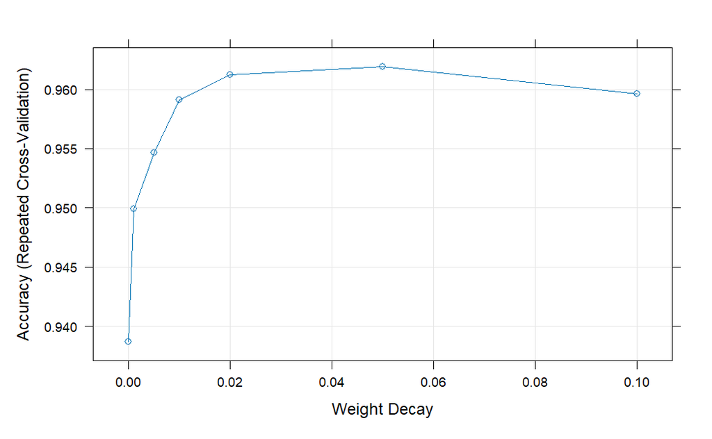

```r
ctrl <- trainControl(method = "repeatedcv", number = 10, repeats = 10)
nn_grid <- expand.grid(size = 5, decay = c(0, 0.001, 0.005, 0.01, 0.02, 0.05, 0.1))
set.seed(123)

nn_tuned <- train(car_train[, -7], car_train[, 7], method = "nnet",
                   trControl = ctrl, tuneGrid = nn_grid, trace = FALSE)
plot(nn_tuned)
```

## Tuning the Decision Tree (`trials`)

```r
ctrl <- trainControl(method = "repeatedcv", number = 10, repeats = 10)
tree_grid <- expand.grid(model = "tree",
                          trials = c(1, 5, 10, 15, 20, 25, 30, 40, 50, 60, 80, 100),
                          winnow = FALSE)
set.seed(123)

tree_tuned <- train(car_train[, -7], car_train[, 7], method = "C5.0",
                     trControl = ctrl, tuneGrid = tree_grid)
plot(tree_tuned)
```

[output not shown]

# Part 3. Presentation of Specified Results